# Palmer Penguins: Práctica General

### Pablo de Lucía Finkel

Vamos a comenzar la práctica general.

```r
library(plyr)
library(palmerpenguins)
data(package = "palmerpenguins")
```

Ya tenemos todos los datos necesarios para empezar a trabajar. ¡Antes haremos un commit!

Vamos a ver esos pingüinos:

```r
str(penguins)
```

```
## tibble [344 x 8] (S3: tbl_df/tbl/data.frame)
##  $ species          : Factor w/ 3 levels "Adelie","Chinstrap",..: 1 1 1 1 1 1 1 1 1 1 ...
##  $ island           : Factor w/ 3 levels "Biscoe","Dream",..: 3 3 3 3 3 3 3 3 3 3 ...
##  $ bill_length_mm   : num [1:344] 39.1 39.5 40.3 NA 36.7 39.3 38.9 39.2 34.1 42 ...
##  $ bill_depth_mm    : num [1:344] 18.7 17.4 18 NA 19.3 20.6 17.8 19.6 18.1 20.2 ...
##  $ flipper_length_mm: int [1:344] 181 186 195 NA 193 190 181 195 193 190 ...
##  $ body_mass_g      : int [1:344] 3750 3800 3250 NA 3450 3650 3625 4675 3475 4250 ...
##  $ sex              : Factor w/ 2 levels "female","male": 2 1 1 NA 1 2 1 2 NA NA ...
##  $ year             : int [1:344] 2007 2007 2007 2007 2007 2007 2007 2007 2007 2007 ...
```

## Apartado 1

Primero determinaremos el número de pingüinos por especie utilizando una función que toma como argumentos la columna “Species” (x), que es un vector, y la especie en particular que buscamos (value).

Dentro de la función establecemos un loop. Por cada posición
$$penguin$$
, empezando por la primera (1) hasta la última (length(x)), revisará si el segundo argumento (value) se corresponde con la especie de interés en una determinada posición
$$penguin$$
, y añadirá 1 a la cuenta de (value), que empieza en 0.

Así, podemos llamar a la función contadora de especies (nspecies) para cada especie. Toma ya. Conozco los loops porque los aprendí en Python.

```r
nspecies <- function(x, value) {
  count <- 0
  for (penguin in 1:length(x)) {
    if (x[penguin] == value) {
      count <- count + 1
    }
  }
  count
}
nspecies(penguins$species, "Adelie")
```

```
## [1] 152
```

```r
nspecies(penguins$species, "Gentoo")
```

```
## [1] 124
```

```r
nspecies(penguins$species, "Chinstrap")
```

```
## [1] 68
```

Hay 152 adelias, 124 gentoos y 68 barbijos. 344 en total.

El siguiente paso será calcular la media, desviación estándar, los mínimos y los máximos de una serie de parámetros. El paso uno consiste en convertir en objetos las medidas de aleta, pico y masa corporal.

```r
longpico <- penguins$bill_length_mm
profpico <- penguins$bill_depth_mm
longaleta <- penguins$flipper_length_mm
masacorp <- penguins$body_mass_g
```

Ahora bien, hay algunos valores n/a en estas columnas, así que al calcular las funciones, eliminaremos los valores n/a. Así obtenemos los resultados del apartado 1:

```r
mean(longpico, na.rm = TRUE)
```

```
## [1] 43.92193
```

```r
sd(longpico, na.rm = TRUE)
```

```
## [1] 5.459584
```

```r
max(longpico, na.rm = TRUE)
```

```
## [1] 59.6
```

```r
min(longpico, na.rm = TRUE)
```

```
## [1] 32.1
```

```r
mean(profpico, na.rm = TRUE)
```

```
## [1] 17.15117
```

```r
sd(profpico, na.rm = TRUE)
```

```
## [1] 1.974793
```

```r
max(profpico, na.rm = TRUE)
```

```
## [1] 21.5
```

```r
min(profpico, na.rm = TRUE)
```

```
## [1] 13.1
```

```r
mean(longaleta, na.rm = TRUE)
```

```
## [1] 200.9152
```

```r
sd(longaleta, na.rm = TRUE)
```

```
## [1] 14.06171
```

```r
max(longaleta, na.rm = TRUE)
```

```
## [1] 231
```

```r
min(longaleta, na.rm = TRUE)
```

```
## [1] 172
```

```r
mean(masacorp, na.rm = TRUE)
```

```
## [1] 4201.754
```

```r
sd(masacorp, na.rm = TRUE)
```

```
## [1] 801.9545
```

```r
max(masacorp, na.rm = TRUE)
```

```
## [1] 6300
```

```r
min(masacorp, na.rm = TRUE)
```

```
## [1] 2700
```

Sin embargo, estos resultados se pueden organizar mejor creando una lista en la que se calculen todas las funciones requeridas al mismo tiempo para cada vector del data frame (medidas de pico, aletas y masa corporal):

```r
longpico_all <- list(mean = "mean", sd = "sd", max = "max", min = "min")
sapply(longpico_all, do.call, args = list(longpico, na.rm = TRUE))
```

```
##      mean        sd       max       min
## 43.921930  5.459584 59.600000 32.100000
```

```r
profpico_all <- list(mean = "mean", sd = "sd", max = "max", min = "min")
sapply(profpico_all, do.call, args = list(profpico, na.rm = TRUE))
```

```
##      mean        sd       max       min
## 17.151170  1.974793 21.500000 13.100000
```

```r
longaleta_all <- list(mean = "mean", sd = "sd", max = "max", min = "min")
sapply(longaleta_all, do.call, args = list(longaleta, na.rm = TRUE))
```

```
##      mean        sd       max       min
## 200.91520  14.06171 231.00000 172.00000
```

```r
masacorp_all <- list(mean = "mean", sd = "sd", max = "max", min = "min")
sapply(masacorp_all, do.call, args = list(masacorp, na.rm = TRUE))
```

```
##      mean        sd       max       min
## 4201.7544  801.9545 6300.0000 2700.0000
```

Con esto hecho, volvemos a hacer un buen commit.

## Apartado 2

Para realizar gráficos comenzaremos el apartado dos instalando los paquetes que utilizamos el día 3 del curso, por si fueran necesarios, y revisamos que quedan bien instalados.

```r
c("ggplot2", "readr", "dplyr", "ggThemeAssist", "patchwork", "titanic", "easyclimate", "terra", "sf", "ggmap") %in% rownames(installed.packages())
```

```
##  [1] TRUE TRUE TRUE TRUE TRUE TRUE TRUE TRUE TRUE TRUE
```

```r
c("promises","mime", "cachem") %in% rownames(installed.packages())
```

```
## [1] TRUE TRUE TRUE
```

Pasamos a la gráfica. Se pide un gráfico de barras que represente el número de individuos muestreados de cada especie en cada isla, representando las especies en diferentes colores.

Vamos a tirar de las joyas de ggplot. El número de especies será el eje y, las islas el eje x, y las especies será el relleno de color, que tenemos que cambiar acorde a las instrucciones.

Para afinarlo bien, cambiaremos el nombre del eje y, y añadiremos un título:

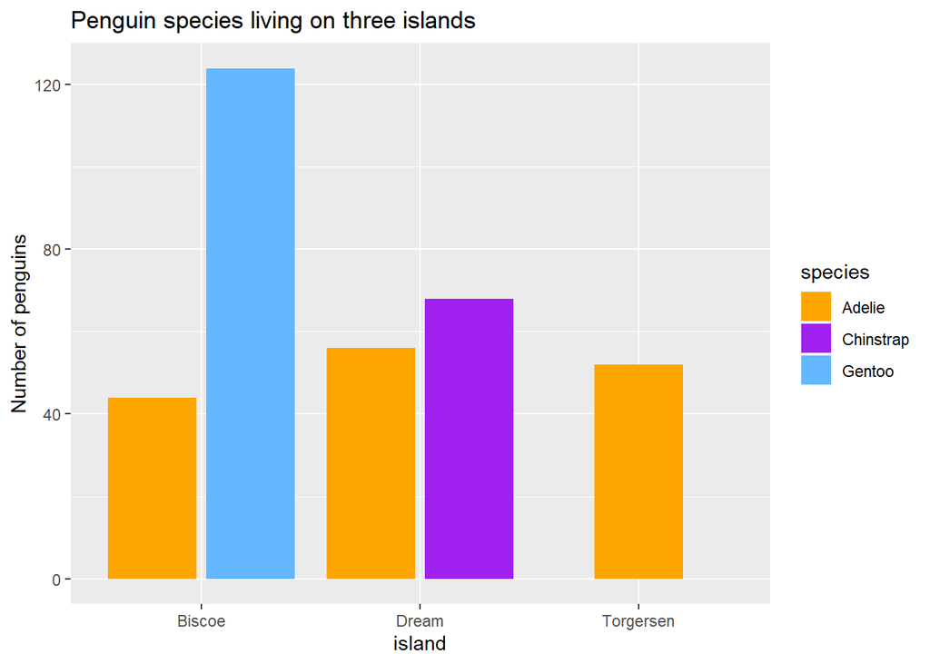

```r
library(ggplot2)
library(dplyr)
ggplot(penguins, aes(x = island, fill = species)) +
  geom_bar(position = position_dodge2(preserve = "single")) +
  scale_fill_manual(values = c("orange", "purple", "steelblue1")) +
  ggtitle("Penguin species living on three islands") +
  ylab("Number of penguins")
```

Con este gráfico ya podemos responder a las dos preguntas de la práctica. Sabemos que la única especie que se ha muestreado en las tres islas es el pingüino de Adelia (mi especie favorita de las 18 que hay). En la isla Dream se han muestreado 56 Adelia y 68 barbijos, siendo un total de 124 pingüinos.

Esto último lo sé porque he utilizado una función dentro del gráfico para mostrar los datos por columna, pero al no saber moverlo u organizarlo bien lo he quitado porque quedaba feo. Aún así, la línea de código que utilicé para verlo fue la siguiente:

stat_count(geom = “text”, size = 2.5, aes(label = ..count..))

Terminamos con otro commit :)

## Apartado 3

En este apartado se nos pide un gráfico de cajas y bigotes donde se compare el tamaño de cada especie de pingüino según su sexo. También usaremos ggplot2.

He visto por el internet pululando una función llamada complete.cases() que elimina todas las filas (o columnas) con datos “n/a”. La he utilizado para eliminar una tercera columna en el boxplot que representa los casos n/a. Ha eliminado 11 filas y queda bien.

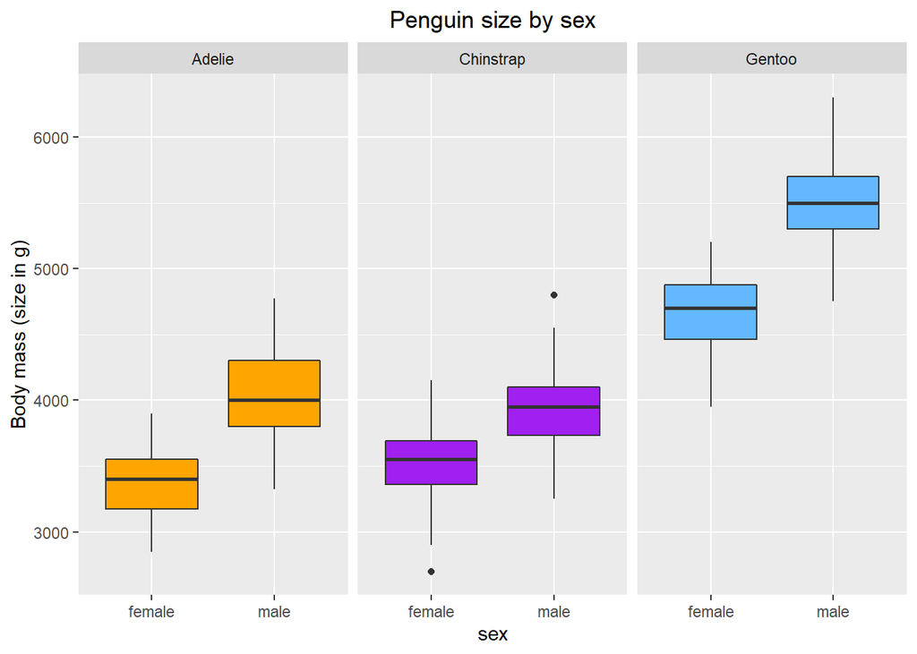

```r
penguins_complete <- penguins[complete.cases(penguins), ]

ggplot(data = penguins_complete) +
  geom_boxplot(aes(x = sex, y = body_mass_g),
               fill = c("orange", "orange", "purple",
                        "purple", "steelblue1", "steelblue1")) +
  facet_wrap(facets = vars(species), ncol = 3) +
  ggtitle("Penguin size by sex") +
  theme(plot.title = element_text(hjust = 0.5)) +
  ylab("Body mass (size in g)")
```

Este gráfico nos indica que la especie de mayor tamaño son los pingüinos Gentoo, que en Sudamérica llaman los “Juanito”. El Barbijo, sin embargo, es la especie cuyas hembras y machos tienen el tamaño más parecido.

Con este gráfico acabamos la práctica general. Permitidme añadir que ha sido muy especial no solo porque ha sido mi primera experiencia en programación, también porque amo a los pingüinos, y algún día iré a verlos a la Antártida.

Terminamos con el último commit ya y lo pasamos a HTML.

-Pablo L. Finkel